# A5 - Routing

Jiangtao, Joyal and Bhanu

October 12, 2017

# Problem

http://janvitek.org/pdpmr/f17/task-a5-routes.html

# Solution

## 1. RouteComputeJob

The job takes as `input` the airline dataset from year 1987-2015 and a `query` file, and outputs two files namely `test-r-00000` and `train-r-00000`. Each of the output file serves purposes as shown below:

```
 For Query A->B, let a Route be A->C->B.
 Then, LegOne Flight : A->C and LegTwo Flight : C->B
```

[output not shown]

### 1a. RouteComputeMapper

The mapper has the following instance members:

| Variable | Description |
| --- | --- |
| srcToDesMap | It represents source-destination connected graph |
| desToSrcMap | It represents destination-source connected graph |
| queryList | List of all query tuples in format of Year, Month, Day, Origin, Destination (e.g. 2001, 09, 11, DEN, DCA) where Year is the same for all tuples |
| yearSet | All Unique years in query tuple. Currently program runs assuming there would be single year for all query tuples |

#### Setup Phase

Each mapper will have shared access to `queryList`. In setup phase, the `queryList` is populated with each row tuple from input query file. Apart from this, the `srcToDesMap` (source-destination map) and desToSrcMap also gets populated. This is done as shown below:

Assume that for a given query file we have following values:

| Date | Source | Destination |
| --- | --- | --- |
| 2011-01-01 | BOS | SEA |
| 2011-02-03 | BOS | ATL |
| 2011-10-11 | ATL | JFK |
| 2011-08-12 | BOS | JFK |
| 2011-06-25 | BOS | SEA |
| 2011-12-25 | ATL | FLO |

As shown in the above table, there are two unique sources (`BOS` and `ATL`) and four unique destinations (`SEA`,`ATL`,`JFK`,`FLO`).

The `srcToDesMap` will be populated with following key,value pairs

| Key | Value |
| --- | --- |
| BOS | {SEA, ATL, JFK} |
| ATL | {JFK, FLO} |

The `desToSrcMap` will be populated with following key,value pairs

| Key | Value |
| --- | --- |
| SEA | {BOS} |
| ATL | {BOS} |
| JFK | {BOS, ATL} |
| FLO | {ATL} |

The below procedure shows exactly these instance variables are used to emit keys from mapper.

1. With the given query data, assume that in current mapper input record, we get a flight=`f1` with Origin=`BOS` and Destination=`C`.
2. For `f1`, will check whether `f1.origin` matches any of the keys in the `srcToDesMap`. In this scenario, `f1.origin` matches to `srcToDesMap`’s key `BOS`, which has 3 unique destinations. Thus will emit three set of keys:

   ```
   <BOS-C-SEA>
   <BOS-C-ATL>
   <BOS-C-JFK>
   ```

   The value for each of these keys will have a flag set to `1`, indicating this is a flight for **Leg 1**.
3. For each mapper input we will also check whether the destination matches any of the key in `desToSrcMap`. Suppose we get a flight=`f2` with Origin=`C` and Destination=`SEA`. Now as `f2.destination` matches with desToSrcMap’s `SEA` we will emit only one key(`SEA` in `desToSrcMap` has one unique source):

   ```
   <BOS-C-SEA>
   ```

   The value for each of such keys will have a flag set to `2`, indicating this is a flight for **Leg 2**.

#### Mapper Phase

The mapper reads each line from flight record csv file, cleans data as per given sanity rules(in A4) and emits 2 kind of pair. Given a year, it emits test data in that year and train data **not** in that year. The `key` is of type `RouteKey` which implements `WritableComparable` while the `value` is of type `FlightData` which implements `Writable`.

```
# RouteComputeMapper Input k,v
LongWritable, Text
# RouteComputeMapper Output k,v
RouteKey, FlightData
```

#### RouteKey

The structure of `RouteKey` is as shown below:

```java
public class RouteKey implements WritableComparable<RouteKey> {
  private Text source;
  private Text hop;
  private Text destination;
  private IntWritable type;//1-Train;2-Test
  private Text date;//yyyyMMdd
}
```

The following are the differences between the implementation of mapper for train and test data.

1. For **train** dataset the value for `RouteKey.type` would be **1**, while for test dataset the value for the `RouteKey.type` would be **2**.
2. For **train** dataset, mapper emits leg1 and leg2 flight.

   For example, if the query year is `2001` and the user has specified `3` years for model generation, then the train dataset will contain data for years **`{1998,1999,2000}`**.

   For **test** dataset, mapper emits leg1 and leg2 flight for query year value. So, in the above example, the test dataset will only contain data for year **`2001`**.
3. There is one more corner case handled for the test phase. Suppose, for a given route A->C->B, where A is the source, C is the hop and B is the destination, if the flight reaches C at 2330 hours for a given date, and the next flight from C to B is at 0030 for the next date, then for test data a new set of pair will be emitted where the key will have date for next day.

#### FlightData

The structure of `FlightData` is as shown below:

```java
public class FlightData implements Writable {
  public static final String SEP_COMMA = ",";
  /**
   * LegType is the flight type in one complete route.
   * If the route is A->C->B
   * LegType=1 -> Flight A-C
   * LegType=2 -> Flight C-B
   */
  private IntWritable legType;
  private IntWritable year;//YEAR
  private IntWritable month;//MONTH
  private IntWritable dayOfWeek;//DAY_OFF_WEEK
  private IntWritable dayOfMonth;//DAY_OF_MONTH
  private IntWritable hourOfDay;//Computed from
  private IntWritable flightId;//FL_NUM
  private Text carrier;//UNIQUE_CARRIER
  private Text origin;//ORIGIN
  private Text dest;//DEST
  private Text schDepTime;//CRS_DEP_TIME (local time: hhmm)
  private Text actDepTime;//DEP_TIME (local time: hhmm)
  private Text schArrTime;//CRS_ARR_TIME (local time: hhmm)
  private Text actArrTime;//ARR_TIME (local time: hhmm)
  private FloatWritable arrDelay;//NORMALISED_DELAY
  private FloatWritable depDelay;//NORMALISED_DELAY
  private Text schElapsedTime;//CRS_ELAPSED_TIME (hhmm)
  private Text actElapsedTime;//ELAPSED_TIME (hhmm)
  private BooleanWritable cancelled;////CANCELLED
}
```

### 1b. RouteComputeReducer

The Reducer phase receives input and emits output in the following `<k,v>` format

```
# RouteComputeReducer Input k,v
RouteKey, FlightData
# RouteComputeReducer Output k,v
RouteKey, RouteData
```

The reducer generates the training and testing data sets and its implementation differs as following.

```
 For Train
 Input:
  - Key: <RouteKey> With RouteKey.type = 1
  - Iterator<FlightData>:  All LegOne and LegTwo Flights for given Key

 Output: Emits every two hop route for the given key in the following format,
  - Key : <RouteKey>
  - Value: <RouteData> With RouteData.isValid as label, depending upon actual layover time at the hop.
  (This label is used to train the model)
```

```
 For Test
 Input:
  - Key: <RouteKey> With RouteKey.type = 2
  - Iterator<FlightData>:  All LegOne and LegTwo Flights for given Key

 Output: Emits every two hop route for the given key in the following format,
  - Key : <RouteKey>
  - Value: <RouteData> With RouteData.isValid as label, depending upon actual layover time at the hop.
  (This label is only used to validate the predictions from the model)
```

# Prediction

After generating test/train data through the MR job we use KNN classifier to predict labels for the test routes.

*Please note that label=1 is an invalid route and label=2 is a valid route.*

*Prediction and scoring are done in R.*

## Train Data Set

The complete train dataset contains 23K observations, but due to compute bottleneck in R, we randomly sampled training data to 10,000. Thus there are 10,000 rows, 8 features, and 1 label.

```
## [1] 10000     9
```

Below are the features we selected for the model. These features basically predict on the seasonal delay trend.

```
## Classes 'data.table' and 'data.frame':   10000 obs. of  9 variables:
##  $ l1.month     : int  7 12 11 10 6 2 12 12 11 9 ...
##  $ l1.dayOfWeek : int  2 4 7 2 3 2 3 3 2 6 ...
##  $ l1.dayOfMonth: int  20 2 28 12 23 9 8 22 9 18 ...
##  $ l1.hourOfDay : int  9 10 8 8 15 17 7 12 7 21 ...
##  $ l2.month     : int  7 12 11 10 6 2 12 12 11 9 ...
##  $ l2.dayOfWeek : int  2 4 7 2 3 2 3 3 2 6 ...
##  $ l2.dayOfMonth: int  20 2 28 12 23 9 8 22 9 18 ...
##  $ l2.hourOfDay : int  17 10 18 10 12 17 15 14 12 9 ...
##  $ label        : Factor w/ 2 levels "1","2": 2 1 2 1 1 1 2 1 2 2 ...
##  - attr(*, ".internal.selfref")=<externalptr>
```

## Test Data Set

Test set has 877 observations distributed over 8 features. These observations are all the possible two hop routes for the given input query.

```
## [1] 877   8
```

```
## Classes 'data.table' and 'data.frame':   877 obs. of  8 variables:
##  $ l1.month     : int  10 10 10 10 10 10 10 2 2 2 ...
##  $ l1.dayOfWeek : int  6 6 6 6 6 6 6 1 1 1 ...
##  $ l1.dayOfMonth: int  1 1 1 1 1 1 1 21 21 21 ...
##  $ l1.hourOfDay : int  17 18 17 7 13 8 12 17 17 17 ...
##  $ l2.month     : int  10 10 10 10 10 10 10 2 2 2 ...
##  $ l2.dayOfWeek : int  6 6 6 6 6 7 7 1 1 2 ...
##  $ l2.dayOfMonth: int  1 1 1 1 1 2 2 21 21 22 ...
##  $ l2.hourOfDay : int  9 9 9 9 9 9 9 8 7 7 ...
##  - attr(*, ".internal.selfref")=<externalptr>
```

## KNN Classifier

While training a classifier we are using repeated cross validation to optimize the model parameters such as k(no of neighbors). Additionally there is a data normalization and scaling for features before feeding to the classifier.

```
## k-Nearest Neighbors
##
## 10000 samples
##     8 predictors
##     2 classes: '1', '2'
##
## Pre-processing: centered (8), scaled (8)
## Resampling: Cross-Validated (10 fold, repeated 3 times)
## Summary of sample sizes: 9000, 9000, 9001, 9000, 8999, 9000, ...
## Resampling results across tuning parameters:
##
##   k   Accuracy   Kappa
##    5  0.8845352  0.7045393
##    7  0.8857669  0.7058633
##    9  0.8850676  0.7024658
##   11  0.8856679  0.7029536
##   13  0.8847668  0.6999338
##   15  0.8842334  0.6974951
##   17  0.8841341  0.6964547
##   19  0.8837675  0.6949189
##   21  0.8829675  0.6920803
##   23  0.8824675  0.6902165
##
## Accuracy was used to select the optimal model using  the largest value.
## The final value used for the model was k = 7.
```

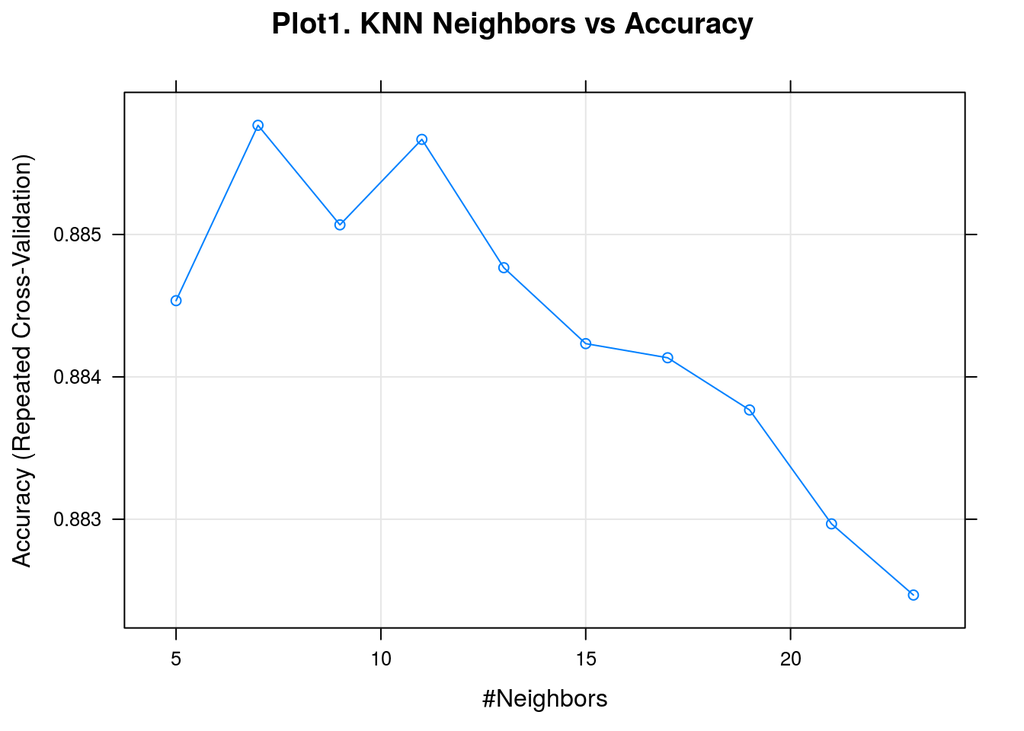

`Plot 1.` shows accuracy per k. With parameter optimization we found the that `k=7` is giving best accuracy of `0.8857669`.

## Confusion Matrix

```
## Confusion Matrix and Statistics
##
##           Reference
## Prediction   1   2
##          1 611  59
##          2 125  82
##
##                Accuracy : 0.7902
##                  95% CI : (0.7617, 0.8167)
##     No Information Rate : 0.8392
##     P-Value [Acc > NIR] : 0.9999
##
##                   Kappa : 0.3462
##  Mcnemar's Test P-Value : 1.652e-06
##
##             Sensitivity : 0.8302
##             Specificity : 0.5816
##          Pos Pred Value : 0.9119
##          Neg Pred Value : 0.3961
##              Prevalence : 0.8392
##          Detection Rate : 0.6967
##    Detection Prevalence : 0.7640
##       Balanced Accuracy : 0.7059
##
##        'Positive' Class : 1
##
```

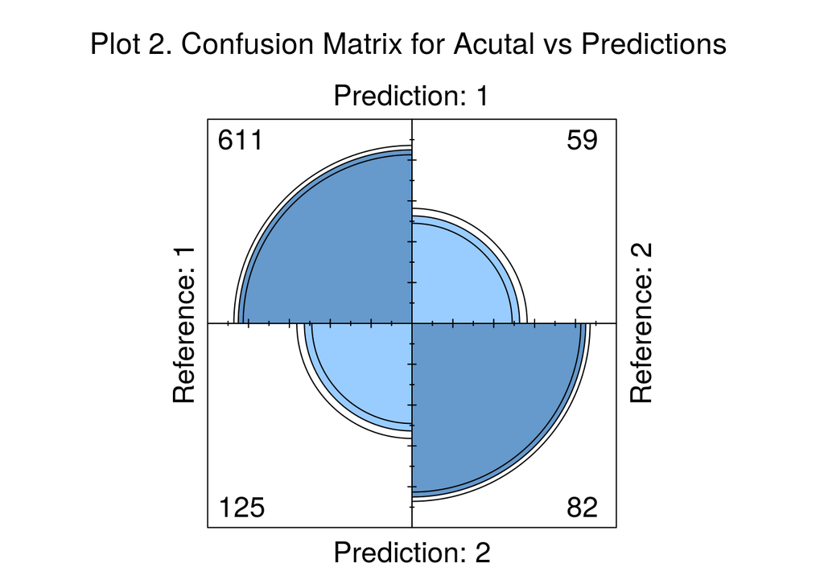

`Plot 2.` is a confusion matrix, that gives direct comparison between our prediction labels and actual test labels.

# Results

## Input Queries

We randomly picked 10 inputs for the same year as follows,

[output not shown]

## Ouput Routes

These are the valid(label=2) 2 hop routes(#207) generated by our model for given 10 input queries.

| flightDate | origin | des | l1.actDepTime | l1.actArrTime | l1.carrier | l1.origin | l1.dest | l2.actDepTime | l2.actArrTime | l2.carrier | l2.origin | l2.dest |
| --- | --- | --- | --- | --- | --- | --- | --- | --- | --- | --- | --- | --- |
| 20111001 | BOS | SEA | 658 | 943 | AA | BOS | DFW | 1852 | 2103 | AS | DFW | SEA |
| 20111001 | BOS | SEA | 559 | 854 | AA | BOS | DFW | 1852 | 2103 | AS | DFW | SEA |
| 20110411 | BOS | DEN | 604 | 908 | B6 | BOS | FLL | 1441 | 1722 | F9 | FLL | DEN |
| 20110411 | BOS | DEN | 604 | 908 | B6 | BOS | FLL | 1458 | 1722 | F9 | FLL | DEN |
| 20111001 | BOS | SEA | 723 | 1036 | CO | BOS | IAH | 1441 | 1701 | CO | IAH | SEA |
| 20110411 | BOS | DEN | 820 | 1157 | UA | BOS | LAX | 2053 | 2348 | MQ | LAX | DEN |
| 20110411 | BOS | DEN | 820 | 1157 | UA | BOS | LAX | 1530 | 1830 | F9 | LAX | DEN |
| 20110411 | BOS | DEN | 820 | 1157 | UA | BOS | LAX | 2019 | 2313 | F9 | LAX | DEN |
| 20110411 | BOS | DEN | 820 | 1157 | UA | BOS | LAX | 2011 | 2310 | F9 | LAX | DEN |
| 20110411 | BOS | DEN | 820 | 1157 | UA | BOS | LAX | 1739 | 2033 | UA | LAX | DEN |
| 20110411 | BOS | DEN | 820 | 1157 | UA | BOS | LAX | 1727 | 2032 | UA | LAX | DEN |
| 20110411 | BOS | DEN | 820 | 1157 | UA | BOS | LAX | 1527 | 1820 | UA | LAX | DEN |
| 20110411 | BOS | DEN | 820 | 1157 | UA | BOS | LAX | 1825 | 2119 | UA | LAX | DEN |
| 20110411 | BOS | DEN | 820 | 1157 | UA | BOS | LAX | 1828 | 2128 | UA | LAX | DEN |
| 20110411 | BOS | DEN | 820 | 1157 | UA | BOS | LAX | 2050 | 2339 | MQ | LAX | DEN |
| 20110411 | BOS | DEN | 820 | 1157 | UA | BOS | LAX | 1928 | 2214 | WN | LAX | DEN |
| 20110411 | BOS | DEN | 820 | 1157 | UA | BOS | LAX | 1556 | 1853 | WN | LAX | DEN |
| 20110411 | BOS | DEN | 820 | 1157 | UA | BOS | LAX | 1949 | 2254 | WN | LAX | DEN |
| 20110411 | BOS | DEN | 820 | 1157 | UA | BOS | LAX | 1540 | 1840 | WN | LAX | DEN |
| 20110411 | BOS | DEN | 909 | 1237 | B6 | BOS | LAX | 2053 | 2348 | MQ | LAX | DEN |
| 20110411 | BOS | DEN | 909 | 1237 | B6 | BOS | LAX | 1530 | 1830 | F9 | LAX | DEN |
| 20110411 | BOS | DEN | 909 | 1237 | B6 | BOS | LAX | 2019 | 2313 | F9 | LAX | DEN |
| 20110411 | BOS | DEN | 909 | 1237 | B6 | BOS | LAX | 2011 | 2310 | F9 | LAX | DEN |
| 20110411 | BOS | DEN | 909 | 1237 | B6 | BOS | LAX | 1739 | 2033 | UA | LAX | DEN |
| 20110411 | BOS | DEN | 909 | 1237 | B6 | BOS | LAX | 1727 | 2032 | UA | LAX | DEN |
| 20110411 | BOS | DEN | 909 | 1237 | B6 | BOS | LAX | 1527 | 1820 | UA | LAX | DEN |
| 20110411 | BOS | DEN | 909 | 1237 | B6 | BOS | LAX | 1825 | 2119 | UA | LAX | DEN |
| 20110411 | BOS | DEN | 909 | 1237 | B6 | BOS | LAX | 1828 | 2128 | UA | LAX | DEN |
| 20110411 | BOS | DEN | 909 | 1237 | B6 | BOS | LAX | 2050 | 2339 | MQ | LAX | DEN |
| 20110411 | BOS | DEN | 909 | 1237 | B6 | BOS | LAX | 1928 | 2214 | WN | LAX | DEN |

[output cut: 177 more lines]

## Scores

The score shown here is exactly what was asked in the assigment.

`Scoring: 1 point per flight if the flight arrives on time at the destination, -100 per proposed flight that does not arrive on time or is cancelled`.

| Score | -10499 |
| --- | --- |
| Total Valid Route Count | 207 |
| Delay Route Count | 106 |
| NonDelay Route Count | 101 |

The score above does not reflect whether the routes are correct or not. All 207 routes are valid routes, with permissible layover time. The score is low due to the fact that 106 routes were delayed (though still valid).

# Job Execution

## Psuedo Distributed

Used the below machine, to run the job in Pseudo Distributed mode.

```
OS: OSX
Processor Name: Intel Core i7
Processor Speed:    2.8 GHz
Number of Processors:   1
Total Number of Cores:  4
L2 Cache (per Core):    256 KB
L3 Cache:   6 MB
Memory: 16 GB
SSD: 256 GB
```

The job took 14.5m to run on the complete corpus. Below are some important observations,

- Input of 6.55 GB(for 337 items) was reduced to train-data(41.6 MB) and test-data(158.6 KB)
- Total input files to process : 337 and Number of splits:337. Per file per mapper which is expected default behavior.

## AWS EMR

Ran the same job on 4 cluster m4.xlarge EMR. The entire corpus took 10.4m to run. There is not much improvement because the data not big enough to produce any noticeable results. Also there is network i/o between distributed mappers and reducer causing some delay.

# Work Breakdown

- **Design** : Bhanu , Joyal, Jiangtao
- **Implementaion** : Bhanu , Joyal, Jiangtao
- **Reporting** : Bhanu , Joyal
- **Execution** : Jiangtao, Bhanu
- **Documentation** : Jiangtao, Joyal